# Mergers of complements: the case of Claro, Colombia

November 07, 2015

## Intro

## Introduction

Mergers of firms producing complementary goods have not received the attention they deserve:

- There is only a handful of papers modeling mergers with complements.
- The FTC merger guidelines do not include a single mention to this sort of mergers.

We have an idea about what would happen if firms only decide prices:

- The merged firm will lower the prices of the bundled goods and increase the price of individual components.
- The outsiders will lower prices also but less than the merged entity.
- The effect on consumer's welfare is not clear.
- The merged firm does R&D at its rivals expense.

We (still) don't know what would happen if firms also decide quality:

- The merged firm increases quality relative to the pre-merger situation.  
  -The effects on consumer welfare are even harder to understand.

## Why care about these mergers?

- These mergers happen all the time:  
  -Apple buying Beats and Metaio.  
  -Dell buying \(EMC^2\).  
  -IBM buying Explorys and Phytel (healthcare analytics).
- The telecom sector is prone to mergers of this sort.
  - Convegence in services ("triple play").
- Technological convergence turns complements into substitutes:  
  -Cellphones and phones.  
  -Netflix and Cable TV.  
  -Laptops and desktops.
- Although not horizontal mergers, which is the focus of the FTC Guidelines, this kind of events could have anticompetitive effects.  
  -Technological convergence is turning complements into substitutes (Cellphones and phones; Netflix and Cable TV; Laptops and desktops).
- Such mergers can alter the incentives for future innovation.
- On a more local note: The case I study caused quite a stir in Colombia.

## This paper

- Goals of this paper:
  - Offer intuition as to why would firms provide higher quality after a merger.
  - Provide evidence on whether quality increases after a merger of complements.
- I study a 2012 merger that took place in Colombia's telecommunications sector:
  - Comcel (the largest cellphone carrier) and Telmex (the largest Internet Service Provider) merged in June that year.
- Contribution relative to literature:
  - Theory about mergers with complements is sparse ( Choi (2008), Flores-Fillol and Moner-Colonques (2011), Anderson, Loertscher, and Schneider (2010)).
  - Empirical papers are inexistent.

## The Claro merger

In June 2012 Colombia's largest cellphone carrier (Comcel) and the largest ISP (Telmex) merged.

The merger allowed Claro, the name given to the merged entity, to sell bundled services. The individual components remained available to subscribers.

[figure not shown]

There were other events that occur around the same time: - In the first quarter of 2012, Telefonica gained control of Coltel. - At the end of 2011 the government reduced the tariffs on computers from 5% to 0%. - Starting on 2013 a tax reform exempted poorer households from paying taxes on internet service purchases. - Starting on September 2012 the price of internet plans was subsidized for poorer households.

## Remainder of the talk

## Outline

- Simple model of merger with complements and quality.
- Data
  - Graphs and summary stats
- Analytic framework
- Results
- Conclusions

## A simple model of mergers with quality: pre-merger profits

There are 2 type of goods which happen to be complementary: \(A\) goods and \(B\) goods. The demand faced by firms producing \(A\) and \(B\) goods are given by

\[Q_i = Q_i^A(p,q), Q_j = Q_j^B(p,q)\]

where \(p\) and \(q\) are vectors.

Before the merger a firm selling \(A\) goods maximizes profits by choosing a price \(p_i\) and a level of quality \(q_i\). The problem for the firm is then

\[ \max_{p_i, q_i} \pi_i(p,q) = p_iQ_i^A(p,q) \]

## A simple model of mergers with quality: FOC

The first-order conditions to this problem are

\(\frac{\partial \pi_i(q_i,p_i)}{\partial p_i} = Q_i^A(p^*,q^*) + p^*_i \frac{\partial Q_i^A(p^*,q^*)}{\partial p_i} = 0\)

\(\frac{\partial \pi_i}{\partial q_i} = p^*_i \frac{\partial Q_i^A(p^*,q^*)}{\partial q_i} = 0\)

## A simple model of mergers with quality: pos-merger profits

If the firm merges with another firm that was producing a complementary good \(j\) with demand \(Q_j(p,q)\) the merged party maximizes \[\pi^M(p,q) = p_iQ^A_i(p,q)+p_jQ^B_j(p,q)\]

The first-order conditions with respect to the price and quality of the original good are:

\(\frac{\partial\pi^M(p,q)}{\partial p_i} = Q^A_i(p^*,q^*) + p^*_i\frac{\partial Q^A_i(p^*,q^*)}{\partial p_i} +\frac{\partial Q^B_j(p^*,q^*)}{\partial p_i} = 0 \)

\(\frac{\partial\pi^M(p,q)}{\partial q_i} = p^*_i\frac{\partial Q^A_i(p^*,q^*)}{\partial q_i} +p^*_j\frac{\partial Q^B_j(p^*,q^*)}{\partial q_i} = 0 \)

The key term here is \(p^*_j\frac{\partial Q_j(p^*,q^*)}{\partial q_i}\). It corresponds to the internalized profits that the firm \(i\) would have not been able to appropriate without the merger.

## The data

- Only Internet (2008-2013):
  - Firm,
  - speeds,
  - price (until 2012q2),
  - technology,
  - strata, and
  - subscribers.
- TV, phone, long distance phone, cellphone(NA), mobile Internet, Internet (2012-2015):
  - Firm,
  - prices,
  - subscribers,
  - strata, and
  - download (created).

I drop some observations: negative prices, implausible speeds, implausible prices and plans that are not residential.

## The internet side of the merger

I can't say much about the cellphone side of the merger. The data corresponding to cellphones is either aggregated at the national level for firms or is missing.

No technological synergies:  
- The merger does not affect the ability of Telmex to provide higher speeds.

The merger was a bit more complex than the stylized model:  
- Claro bundles can contain up to 4 items: phone, TV, broadband and cellphone.  
- I focus on the effect of the merger on broadband services.

## Speeds before and after the merger

| Average download speed | Average download speed Before Obs. | Average download speed Before Speed | Average download speed | Average download speed After Obs. | Average download speed After Speed | Average download speed | Average download speed Diff. | Average download speed | Average download speed 95% Conf. int. LB | Average download speed 95% Conf. int. UB |
| --- | --- | --- | --- | --- | --- | --- | --- | --- | --- | --- |
| None in town | 4,065 | 1.19 |  | 4,836 | 1.86 |  | 0.67 |  | 0.62 | 0.72 |
| Telmex in town | 4,794 | 2.54 |  | 5,531 | 3.61 |  | 1.06 |  | 0.96 | 1.16 |
| Coltel in town | 7,542 | 1.52 |  | 7,554 | 1.69 |  | 0.17 |  | 0.14 | 0.20 |
| Both in town | 13,544 | 2.36 |  | 17,233 | 3.15 |  | 0.79 |  | 0.73 | 0.84 |

<sub>Download speed in Mb/s. Before: 2010q4-2012q2. After: 2012q3-2013q4</sub>

Even though all cities experienced an increase in download speeds, the two largest increases happened in cities where Telmex operated alone and where it competed with Coltel.

## Subscribers before and after the merger

| Average number of subscribers | Average number of subscribers Before Obs. | Average number of subscribers Before Subsc. | Average number of subscribers | Average number of subscribers After Obs. | Average number of subscribers After Subsc. | Average number of subscribers | Average number of subscribers Diff. | Average number of subscribers | Average number of subscribers 95% Conf. int. LB | Average number of subscribers 95% Conf. int. UB |
| --- | --- | --- | --- | --- | --- | --- | --- | --- | --- | --- |
| None in town | 4,065 | 151.14 |  | 4,836 | 160.83 |  | 9.69 |  | -4.85 | 24.24 |
| Telmex in town | 4,794 | 937.49 |  | 5,531 | 836.45 |  | -101.04 |  | -250.77 | 48.69 |
| Coltel in town | 7,542 | 117.73 |  | 7,554 | 143.62 |  | 25.89 |  | 17.28 | 34.49 |
| Both in town | 13,544 | 987.20 |  | 17,233 | 929.30 |  | -57.90 |  | -168.72 | 52.92 |

<sub>Number of subscribers by plan. Before: 2010q4-2012q2. After: 2012q3-2013q4</sub>

The number of subscribers seem to have increased in cities served by Coltel, but did not change much in other cities.

## Variety before and after the merger

| Average number of plans offered by each firm | Average number of plans offered by each firm Before Obs. | Average number of plans offered by each firm Before Plans | Average number of plans offered by each firm | Average number of plans offered by each firm After Obs. | Average number of plans offered by each firm After Plans | Average number of plans offered by each firm | Average number of plans offered by each firm Diff. | Average number of plans offered by each firm | Average number of plans offered by each firm 95% Conf. int. LB | Average number of plans offered by each firm 95% Conf. int. UB |
| --- | --- | --- | --- | --- | --- | --- | --- | --- | --- | --- |
| None in town | 4,065 | 8.16 |  | 4,836 | 10.25 |  | 2.09 |  | 1.76 | 2.43 |
| Telmex in town | 4,794 | 35.46 |  | 5,531 | 36.58 |  | 1.12 |  | 0.02 | 2.22 |
| Coltel in town | 7,542 | 7.18 |  | 7,554 | 7.60 |  | 0.42 |  | 0.28 | 0.55 |
| Both in town | 13,544 | 20.79 |  | 17,233 | 24.09 |  | 3.30 |  | 2.97 | 3.63 |

<sub>Number plans offered by a firm in a city. Before: 2010q4-2012q2. After: 2012q3-2013q4</sub>

## Prices before and after the merger

| Average price of a plan | Average price of a plan Before Obs. | Average price of a plan Before Price | Average price of a plan | Average price of a plan After Obs. | Average price of a plan After Price | Average price of a plan | Average price of a plan Diff. | Average price of a plan | Average price of a plan 95% Conf. int. LB | Average price of a plan 95% Conf. int. UB |
| --- | --- | --- | --- | --- | --- | --- | --- | --- | --- | --- |
| None in town | 1,210 | 8.62 |  | 9,217 | 10.96 |  | 2.35 |  | 2.03 | 2.66 |
| Telmex in town | 23,052 | 6.06 |  | 151,639 | 8.12 |  | 2.06 |  | 2.00 | 2.11 |
| Coltel in town | 1,111 | 6.52 |  | 3,935 | 7.14 |  | 0.62 |  | 0.35 | 0.90 |
| Both in town | 99,563 | 4.75 |  | 224,666 | 5.64 |  | 0.89 |  | 0.87 | 0.91 |

<sub>Price per Mbps. Before: 2010q4-2012q2. After: 2012q3-2013q4</sub>

## Telmex increased speeds after the merger

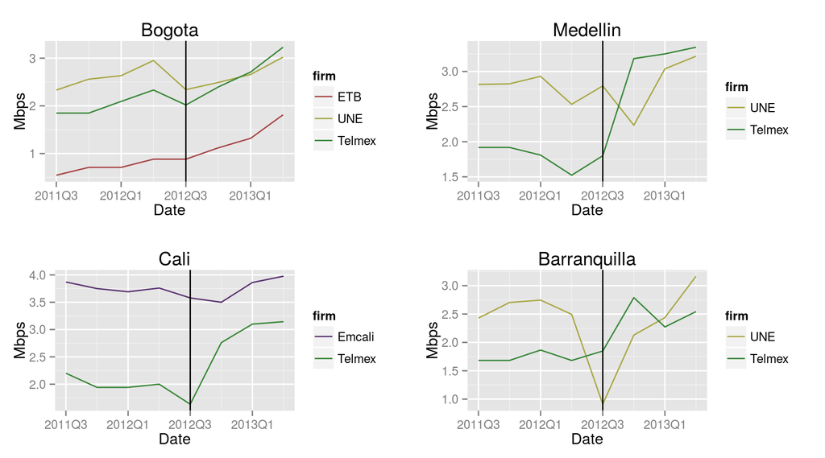

## Mobile traffic seemed to have increased too

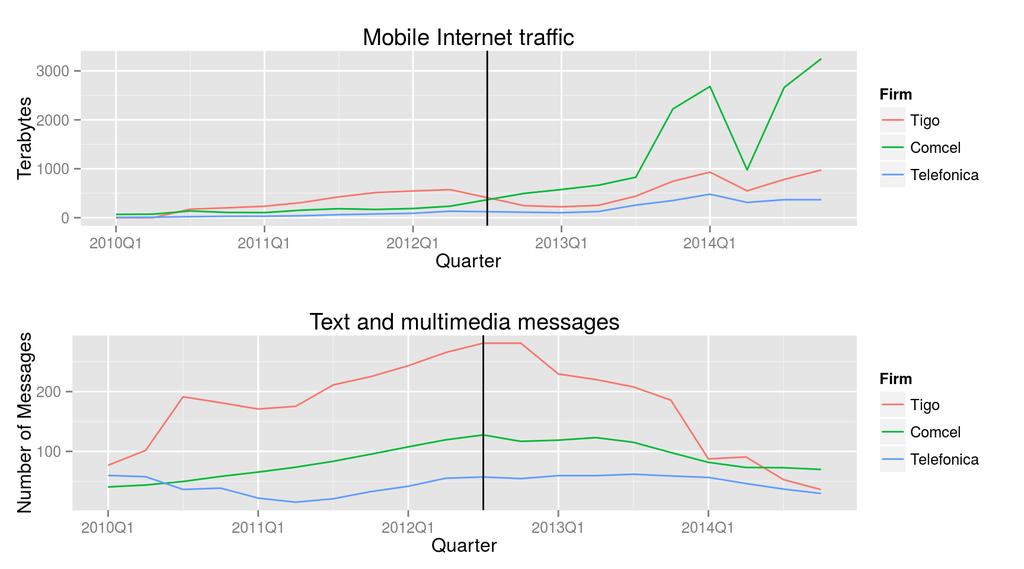

## Telmex reduced prices, but with a lag

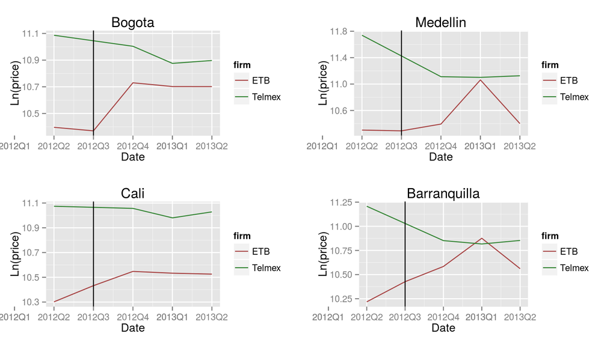

## Fixed effects approach: speed

To capture the effect of the merger on the speeds of plans offered by the merged company and its rivals I estimate the following equation:

\[ speed_{ijct} = \mu + \delta_{st} + \alpha_j + \gamma_1 coltel\_merged_{jt} + \gamma_2 telmex\_merged_{jt} + \phi_1 competes\_with\_merged\_coltel_{jt} + \\ \phi_2 competes\_with\_merged\_telmex_{jt} + \phi_3 competes\_with\_both_{jt} + \varepsilon_{ijct} \]

- \(speed\) refers to the advertised download speed measured in Mbps.
- indexes are: \(i\) plans; \(j\) firms; \(c\) identifies cities; \(t\) identifies quarters.
- Standard errors are clustered at city/quarter/firm level.

The \(\gamma\)s capture the effect of the mergers on the merged companies while the \(\phi\)s capture the effect on competitors. Alternatively I use as measures of quality, the minimum and median speeds offered in a market.

## Fixed effects approach: price

To get the effect on prices I use a similar approach. The price data for Coltel however were not available.

\[ \ln price_{ijct} = \mu + \delta_{st} + \alpha_j + \gamma_2 telmex\_merged_{jt} + \phi_1 coltel\_merged\_in\_city_{ct} + \\ \phi_2 telmex\_merged\_in\_city_{ct} + \phi_3 both\_merged\_in\_city_{ct} + \varepsilon_{ijct} \]

- \(price\) refers to unit price (price/Mbps).
- indexes are: \(i\) plans; \(j\) firms; \(c\) identifies cities; \(t\) identifies quarters.
- Standard errors are clustered at city/quarter/firm level.

The \(\gamma\)s capture the effect of the mergers on the merged companies while the \(\phi\)s capture the effect on competitors. Alternatively I use as measures of quality, the minimum and median speeds offered in a market.

## Results

## Effect of merger on speed

| Effect of mergers on speed | Effect of mergers on speed Model 1 | Effect of mergers on speed SE 1 | Effect of mergers on speed S1 | Effect of mergers on speed Model 2 | Effect of mergers on speed SE 2 | Effect of mergers on speed S2 |
| --- | --- | --- | --- | --- | --- | --- |
| Intercept | 0.21 | 0.25 |  | -0.07 | 0.31 |  |
| Coltel | 0.75 | 0.25 | ** | 1.02 | 0.31 | *** |
| Telmex | 2.27 | 0.23 | *** | 2.58 | 0.29 | *** |
| Coltel merged | -0.15 | 0.14 |  | -0.19 | 0.19 |  |
| Telmex merged | 1.47 | 0.15 | *** | 1.57 | 0.22 | *** |
| Competes with Coltel | 0.31 | 0.12 | ** | 0.35 | 0.17 | * |
| Competes with Telmex | 0.61 | 0.19 | ** | 0.64 | 0.27 | * |
| Competes with both | -0.11 | 0.17 |  | -0.02 | 0.23 |  |
| adj. R-squared | 0.25 |  |  | 0.24 |  |  |
| Observations | 53,357 |  |  | 29,073 |  |  |

<sub>Dependent Variable: Advertised download speed(Mbps). Model 1: state and firm-quarter FE. Model 2: same as 1 but drops plans affected by the confounding policies. Signif. codes: 0(***) 0.001(**) 0.01(*) 0.05(.). Standard errors clusetered at firm-city-quarter level.</sub>

Takeaways:  
- After the merger, Telmex's plans increased on average by 1.5 Mbps.  
- Telmex's competitors responded by increasing speeds by .6 Mbps on average.

## Effect of merger on minimum speed

| Effect of mergers on min. speed | Effect of mergers on min. speed Model 1 | Effect of mergers on min. speed SE 1 | Effect of mergers on min. speed S1 | Effect of mergers on min. speed Model 2 | Effect of mergers on min. speed SE 2 | Effect of mergers on min. speed S2 |
| --- | --- | --- | --- | --- | --- | --- |
| Intercept | 1.29 | 0.06 | *** | 1.34 | 0.06 | *** |
| Coltel | -0.99 | 0.06 | *** | -1.04 | 0.06 | *** |
| Telmex | -0.95 | 0.07 | *** | -0.94 | 0.07 | *** |
| Coltel merged | -0.02 | 0.07 |  | 0.03 | 0.07 |  |
| Telmex merged | -0.1 | 0.06 |  | -0.11 | 0.06 | . |
| Competes with Coltel | 0.03 | 0.06 |  | 0.06 | 0.07 |  |
| Competes with Telmex | -0.23 | 0.06 | *** | -0.22 | 0.06 | *** |
| Competes with both | 0.02 | 0.05 |  | 0 | 0.05 |  |
| adj. R-squared | 0.45 |  |  | 0.41 |  |  |
| Observations | 53,357 |  |  | 29,073 |  |  |

<sub>Dependent Variable: Minimum download speed(Mbps). Model 1: state and firm-quarter FE. Model 2: same as 1 but drops plans affected by the confounding policies. Signif. codes: 0(***) 0.001(**) 0.01(*) 0.05(.). Standard errors clusetered at firm-city-quarter level.</sub>

Takeaways:  
- After the merger Telmex's minimum speeds offered to affluent households reduced a bit.  
- Telmex's rivals reduced their minimum speeds.

## Effect of merger on median speed

| Effect of mergers on median speed | Effect of mergers on median speed Model 1 | Effect of mergers on median speed SE 1 | Effect of mergers on median speed S1 | Effect of mergers on median speed Model 2 | Effect of mergers on median speed SE 2 | Effect of mergers on median speed S2 |
| --- | --- | --- | --- | --- | --- | --- |
| Intercept | 0.51 | 0.12 | *** | 0.42 | 0.12 | *** |
| Coltel | 0.25 | 0.12 | * | 0.34 | 0.12 | ** |
| Telmex | 1.12 | 0.15 | *** | 1.18 | 0.16 | *** |
| Coltel merged | -0.12 | 0.14 |  | -0.08 | 0.15 |  |
| Telmex merged | 1.84 | 0.16 | *** | 1.83 | 0.17 | *** |
| Competes with Coltel | 0.27 | 0.09 | ** | 0.29 | 0.11 | ** |
| Competes with Telmex | 0.54 | 0.18 | ** | 0.52 | 0.18 | ** |
| Competes with both | -0.12 | 0.16 |  | -0.11 | 0.17 |  |
| adj. R-squared | 0.66 |  |  | 0.63 |  |  |
| Observations | 53,357 |  |  | 29,073 |  |  |

<sub>Dependent Variable: Median download speed(Mbps). Model 1: state and firm-quarter FE. Model 2: same as 1 but drops plans affected by the confounding policies. Signif. codes: 0(***) 0.001(**) 0.01(*) 0.05(.). Standard errors clusetered at firm-city-quarter level.</sub>

Takeaways:  
-The merger had a greater impact on the median speed. The increase on Telmex's median speed was almost 2 Mbps.

## Results: price

| Estimates of the effect of the mergers | Estimates of the effect of the mergers Model 1 | Estimates of the effect of the mergers SE 1 | Estimates of the effect of the mergers S1 | Estimates of the effect of the mergers Model 2 | Estimates of the effect of the mergers SE 2 | Estimates of the effect of the mergers S2 |
| --- | --- | --- | --- | --- | --- | --- |
| Intercept | 3.44 | 0.11 | *** | 3.42 | 0.11 | *** |
| Telmex | -1.94 | 0.06 | *** | -2.02 | 0.06 | *** |
| Telmex merged | -0.05 | 0.12 |  | -0.02 | 0.12 |  |
| Coltel in city | 0.09 | 0.07 |  | 0.1 | 0.12 |  |
| Coltel post-merger | -0.09 | 0.02 | *** | -0.08 | 0.07 |  |
| Competes with Telmex | -0.08 | 0.03 | * | -0.07 | 0.02 | *** |
| Competes with both | -0.01 | 0.11 |  | -0.02 | 0.03 |  |
| adj. R-squared | 0.74 |  |  | 0.72 |  |  |
| Observations | 294,709 |  |  | 189,784 |  |  |

<sub>Dependent Variable: Natural logarithm of dollars per Mbps. Model 1: state and firm-quarter FE. Model 2: same as 1 but drops plans affected by the confounding policies. Signif. codes: 0(***) 0.001(**) 0.01(*) 0.05(.). Standard errors clusetered at firm-city-quarter level.</sub>

Takeaways:  
- Telmex's unit prices did not change as a result of the merger. Are plans more expensive then? - Telmex's competitors reduced prices.

## Results: median price

| Estimates of the effect of the mergers | Estimates of the effect of the mergers Model 1 | Estimates of the effect of the mergers SE 1 | Estimates of the effect of the mergers S1 | Estimates of the effect of the mergers Model 2 | Estimates of the effect of the mergers SE 2 | Estimates of the effect of the mergers S2 |
| --- | --- | --- | --- | --- | --- | --- |
| Intercept | 3.74 | 0.09 | *** | 3.76 | 0.09 | *** |
| Telmex | -1.88 | 0.06 | *** | -1.92 | 0.05 | *** |
| Telmex merged | 0.03 | 0.15 |  | 0.05 | 0.15 |  |
| Coltel in city | 0.12 | 0.08 |  | 0.09 | 0.08 |  |
| Coltel post-merger | -0.19 | 0.03 | *** | -0.17 | 0.01 | *** |
| Competes with Telmex | -0.14 | 0.04 | ** | -0.12 | 0.06 | * |
| Competes with both | 0.03 | 0.09 |  | 0.02 | 0.09 |  |
| adj. R-squared | 0.97 |  |  | 0.97 |  |  |
| Observations | 363,346 |  |  | 239,350 |  |  |

<sub>Dependent Variable: logarithm of median price per Mbps. Model 1: state and firm-quarter FE. Model 2: same as 1 but drops plans affected by the confounding policies. Signif. codes: 0(***) 0.001(**) 0.01(*) 0.05(.). Standard errors clusetered at firm-city-quarter level.</sub>

Takeaways:  
- Same as before?

## References

## Bibliography

Anderson, Simon P, Simon Loertscher, and Yves Schneider. 2010. “The ABC of Complementary Products Mergers.” *Economics Letters* 106 (3): 212–15. doi:10.1016/j.econlet.2009.11.022. http://dx.doi.org/10.1016/j.econlet.2009.11.022.

Choi, Jay Pil. 2008. “Mergers with Bundling in Complementary Markets*.” *The Journal of Industrial Economics* 56 (3). wiley: 553–77. doi:10.1111/j.1467-6451.2008.00352.x. http://dx.doi.org/10.1111/j.1467-6451.2008.00352.x.

Flores-Fillol, Ricardo, and Rafael Moner-Colonques. 2011. “Endogenous Mergers of Complements with Mixed Bundling.” *Review of Industrial Organization* 39 (3): 231–51. doi:10.1007/s11151-011-9281-0. http://dx.doi.org/10.1007/s11151-011-9281-0.